# Tidybiology Final Project

Evon DeBose-Scarlett  
16 November 2020

### Import Data

I loaded the ‘chromosome’ data, as well as a dataset of detected retroduplication insertions I found from this paper:

Zhang, Y., Li, S., Abyzov, A., & Gerstein, M. B. (2017). Landscape and variation of novel retroduplications in 26 human populations. PLoS computational biology, 13(6), e1005567. https://doi.org/10.1371/journal.pcbi.1005567.

In it, they identify the parent genes and the insertion sites of retroduplication events of 152 parent genes, a subset of the 15,642 total retroduplication events they discovered from 2,533 individuals for 503 unique parent genes.

I saw that this dataframe has 11 variables and 286 observations (some parent genes have multiple retroduplications).

```
## Rows: 286
## Columns: 11
## $ chr                               <chr> "chr14", "chr2", "chr6", "chr6", ...
## $ start                             <dbl> 20833052, 33141544, 147532202, 16...
## $ end                               <dbl> 20833208, 33141586, 147532352, 16...
## $ geneName                          <chr> "FLOT1", "FAM107B", "PRKCE", "PRK...
## $ geneID                            <chr> "ENSG00000137312", "ENSG000000658...
## $ geneChr                           <chr> "chr6", "chr10", "chr2", "chr2", ...
## $ geneStart                         <dbl> 30695485, 14560555, 45878483, 458...
## $ geneEnd                           <dbl> 30710510, 14816896, 46415129, 464...
## $ populations                       <chr> "CHS", "LWK", "GWD", "GWD", "MSL"...
## $ totalReadSupport                  <dbl> 6, 6, 4, 6, 6, 4, 180, 9, 10, 9, ...
## $ `orientation(respect to parents)` <chr> "same", "different", "same", "sam...
```

### EDA

I was curious if there was a pattern to the number of parent gene retroduplications from each chromosome in Zhang et al.’s dataset. Interestingly, some chromosomes have very high numbers of originating retroduplications, and some have very few. Some were not found to have any (21 and Y).

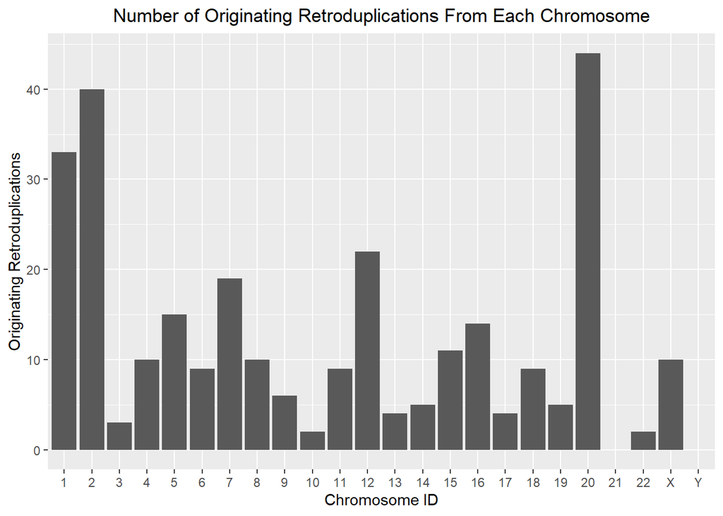

Retroduplication occurs with transcription events (a gene is transcribed into RNA and then reverse transcribed back into DNA and inserted somewhere else in the genome) (Zhang et al., 2017).

This made me curious about the level of transcription on each chromosome. I took a look at the ‘chromosome’ dataset for information about possible RNAs that could be transcribed from each chromosome.

```
## Rows: 24
## Columns: 14
## $ id                     <fct> 1, 2, 3, 4, 5, 6, 7, 8, 9, 10, 11, 12, 13, 1...
## $ length_mm              <dbl> 85, 83, 67, 65, 62, 58, 54, 50, 48, 46, 46, ...
## $ basepairs              <dbl> 248956422, 242193529, 198295559, 190214555, ...
## $ variations             <dbl> 12151146, 12945965, 10638715, 10165685, 9519...
## $ protein_codinggenes    <int> 2058, 1309, 1078, 752, 876, 1048, 989, 677, ...
## $ pseudo_genes           <int> 1220, 1023, 763, 727, 721, 801, 885, 613, 66...
## $ totallongnc_rna        <int> 1200, 1037, 711, 657, 844, 639, 605, 735, 49...
## $ totalsmallnc_rna       <int> 496, 375, 298, 228, 235, 234, 208, 214, 190,...
## $ mi_rna                 <int> 134, 115, 99, 92, 83, 81, 90, 80, 69, 64, 63...
## $ r_rna                  <int> 66, 40, 29, 24, 25, 26, 24, 28, 19, 32, 24, ...
## $ sn_rna                 <int> 221, 161, 138, 120, 106, 111, 90, 86, 66, 87...
## $ sno_rna                <int> 145, 117, 87, 56, 61, 73, 76, 52, 51, 56, 76...
## $ miscnc_rna             <int> 192, 176, 134, 104, 119, 105, 143, 82, 96, 8...
## $ centromereposition_mbp <dbl> 125.0, 93.3, 91.0, 50.4, 48.4, 61.0, 59.9, 4...
```

I looked at the relationship between chromosome length and total possible transcription events.  
Smaller chromosomes tend to have fewer possible transcription events.

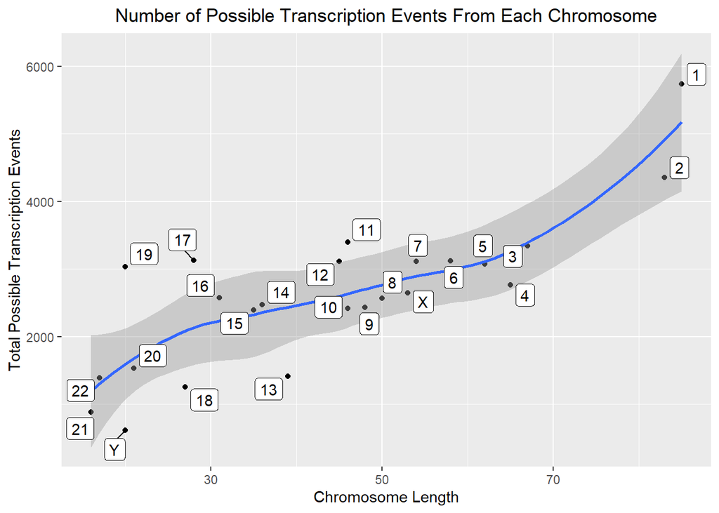

Now, I wanted to know if the number of retroduplication events found originating from each chromosome was related to the number of possible transcription events for each chromosome. I plotted this as a simple scatter plot first, then as a lollipop plot to make the patterns more clear.

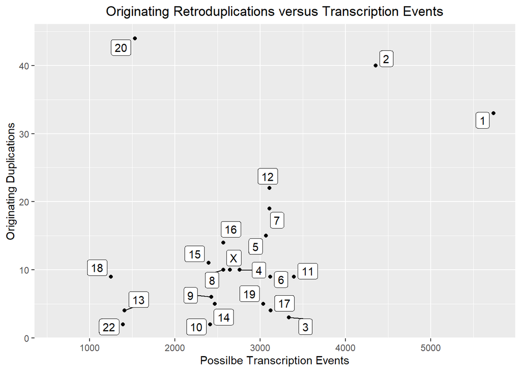

I wondered if normalizing the retroduplications to the number of possible transcription events on each chromosome would clarify a pattern.

### Final Graph

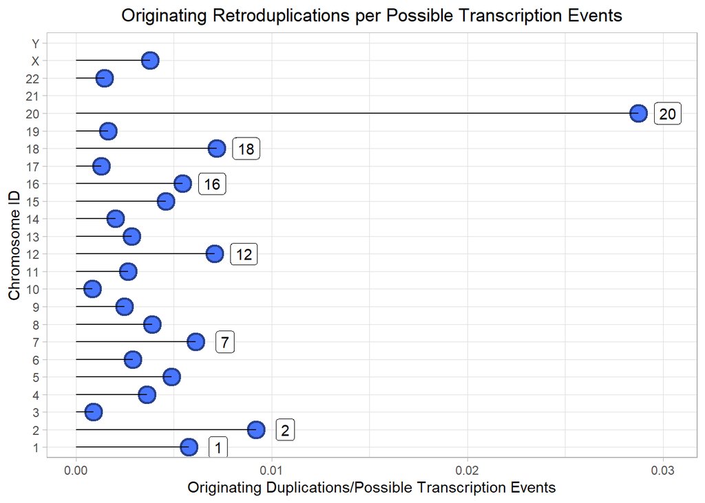

### Conclusions

Based on this graph, it appears that chromosome 20 has far more retroduplication events per possible transcription events originating from it than any other chromosome. This suggests that one or more transcripts from this chromosome are preferentially selected for retroduplication events.

### Prioritized Follow-Up

Looking back at the original dataset, There are multiple retroduplications of the gene *FRG1B* on chromosome 20.

```
## Rows: 38
## Columns: 11
## $ start                             <dbl> 2541916, 5703093, 19316224, 19318...
## $ end                               <dbl> 2542031, 5703390, 19316390, 19318...
## $ geneName                          <chr> "FRG1B", "FRG1B", "FRG1B", "FRG1B...
## $ geneID                            <chr> "ENSG00000149531", "ENSG000001495...
## $ geneStart                         <dbl> 29611856, 29611856, 29611856, 296...
## $ geneEnd                           <dbl> 29634010, 29634010, 29634010, 296...
## $ populations                       <chr> "ACB,CDX,FIN,GBR,IBS,PUR", "ACB,I...
## $ totalReadSupport                  <dbl> 196, 22, 917, 53, 301, 18, 209, 2...
## $ `orientation(respect to parents)` <chr> "same", "same", "same", "same", "...
## $ insertchr                         <chr> "hs37d5", "hs37d5", "hs37d5", "hs...
## $ parentchr                         <chr> "20", "20", "20", "20", "20", "20...
```

I would look at the features of this gene compared to less-duplicated genes to see what features of *FRG1B* make it more prone to retroduplication.

### Acknowledgments

I would like to acknowledge the instructors, the creators of the tidyverse package, the creators of RDocumentation, the creators and contributors to Stack Overflow, and Zhang et al. for the use of their publicly available data.

### Reference

Zhang, Y., Li, S., Abyzov, A., & Gerstein, M. B. (2017). Landscape and variation of novel retroduplications in 26 human populations. PLoS computational biology, 13(6), e1005567. https://doi.org/10.1371/journal.pcbi.1005567